# [Cogsci] IntroStat 5 part3

## 5.2 Families of distributions

이 부분은 꽤 어렵기도 하고... 우선 그렇게 급한 부분은 아니라서 이런 것들이 있다 정도만 이해하고 넘어가셔도 될 것 같습니다.

분포족(families of distributions) 이라는 것은 다양한 분포들에 대해 비슷한 분포들끼리 묶어 놓은 것을 이야기 합니다. 각 분포족은 해당 분포를 규정하는 파라미터들을 갖는 함수(예: exponential 함수)들로 표현됩니다.

### 5.2.1 The d, p, q, and r functions

- d functions: 해당 분포의 p.d.f를 리턴한다.
- p functions: 해당 분포의 c.d.f를 리턴한다
- q functions: 해당 분포의 quantile을 리턴한다
- r functions: 해당 분포에서 random sample을 리턴한다

```r
# 이 말은 0부터 3까지의 범위를 가지는 uniform distribution에서
# f(1)의 값을 return 하라는 이야기입니다.
dunif(x=1, min=0, max=3)
```

0.333333333333333

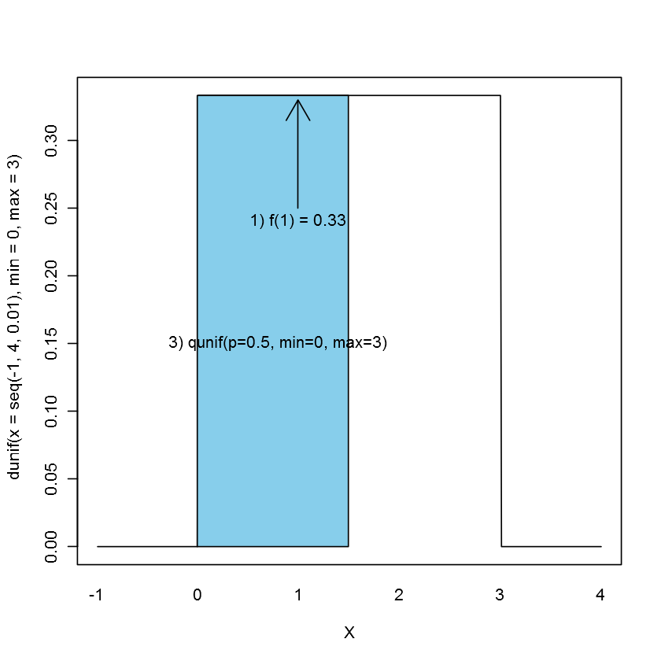

```r
plot(dunif(x=seq(-1,4,0.01), min=0, max=3), type='l', xaxt="n", xlab="X")
axis(1, at=c(0,100,200,300,400,500), labels=seq(-1,4,1), tick=FALSE)
polygon(c(100,100,250,250),c(0,0.33333,0.3333333,0), col="skyblue")
arrows(200,0.25,200,0.33)
text(200,0.24, "1) f(1) = 0.33")
# The shaded area
text(180, 0.15, "3) qunif(p=0.5, min=0, max=3)")
```

```r
# 이건 unif(0,3) 분포에서 X=2의 quantile을 말하라는 뜻. 곧 F(2)
punif(q=2, min=0, max=3)
```

0.666666666666667

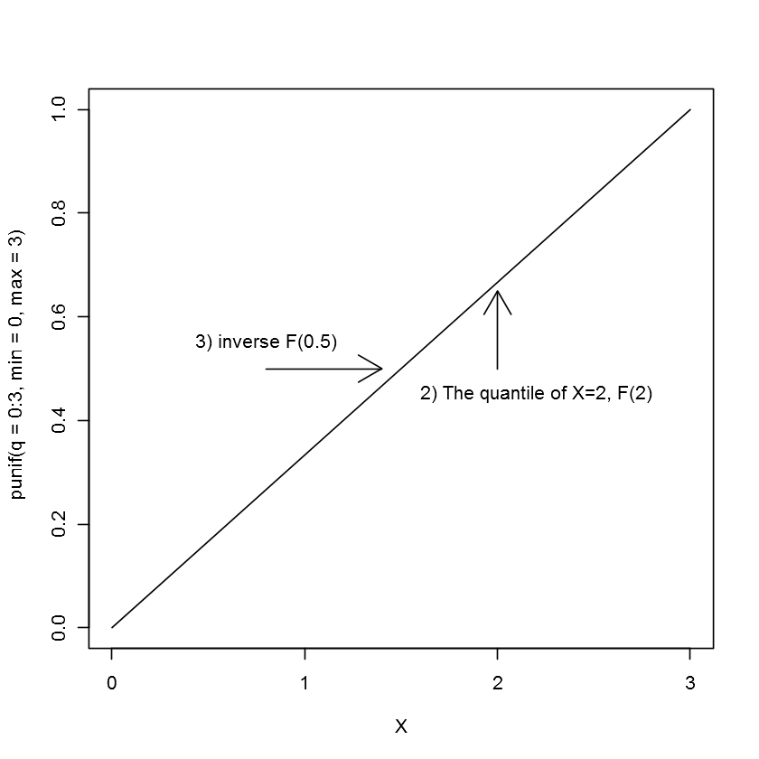

```r
plot(punif(q=0:3, min=0, max=3), type="l",xaxt="n", xlab="X")
axis(1, at=c(1,2,3,4), labels=0:3)
arrows(3,0.5,3,0.65)
text(3.2, 0.45, "2) The quantile of X=2, F(2)")
arrows(1.8, 0.5, 2.4, 0.5)
text(1.8, 0.55, "3) inverse F(0.5)")
```

```r
# 이건 위와 반대로 F 의 역함수
# 곧 unif(0,3)의 F 함수 값을 0.5로 만드는 random variable의 값을 구하라는 뜻.
qunif(p=1/2, min=0, max=3)
```

1.5

```r
# 이건 unif(0,3) 이라는 분포에서 임의의 확률 변수 값들을 n=1개 만큼 뽑아 내라는 뜻
runif(n=1, min=0, max=3)

# 이렇게 하면 10개 추출
runif(10, 0, 3)
```

2.30305278114974

1. 2.65555800567381

2. 1.43330353335477

3. 2.58384581306018

4. 2.66547756269574

5. 1.28741985792294

6. 2.18831623764709

7. 1.98857174883597

8. 2.45205441629514

9. 1.88194103026763

10. 1.86780801764689

[참고]

책에 recycle 나온 부분은 저렇게 d,p,q,r 함수에 들어가는 인자가 벡터 형태이기 때문에, named vector의 경우 name은 recycle이 될 거라는 이야기입니다.

```r
ps <- seq(0,1,0.2)
# unnamed numeric vector
ps
# 그냥 벡터를 넣어주면, unif(0,3) 이라는 분포에서
# 0, 0.2, 0.4, 0.6, 0.8, 1 quantile에 해당하는 random variable들을 리턴할 겁니다.
qunif(ps, min=0, max=3)
# 이제 넣어주는 벡터에 추가적인 argument를 넣어 보겠습니다.
names(ps) <- as.character(seq(0,100,by=20))
# ps 라는 벡터의 원소들에 이제 0, 20, 40, 60, 80, 100 이라는 이름이 생겼습니다.
# 이 이름들은 qunif 에서 사용하는 인자들이 아니기 때문에 recycle이 될 겁니다.
# 그냥 그대로 재사용이 될 거라는 말입니다.
print(ps)
# 변형된 ps를 넣어보겠습니다. 이제 아까 본 random variable 들에
# 이름이 붙은 것을 알 수 있습니다.
print(qunif(ps, min=0, max=3))
```

1. 0

2. 0.2

3. 0.4

4. 0.6

5. 0.8

6. 1

1. 0

2. 0.6

3. 1.2

4. 1.8

5. 2.4

6. 3

```
  0  20  40  60  80 100
0.0 0.2 0.4 0.6 0.8 1.0
  0  20  40  60  80 100
0.0 0.6 1.2 1.8 2.4 3.0
```

```r
# 또, min=, max= argument 값을 sequence로 줘서 한 번에 여러 개 분포에서의 값을
# 구할 수도 있습니다.

# 이렇게 하면 unif(0,1), unif(0,2), unif(0,3), unif(0,4), unif(0,5)의 다섯 개 분포에서
# 각각 하나씩 확률 변수의 값을 추출한다는 의미입니다.
runif(5, min=0, max=1:5)
```

1. 0.573306533740833

2. 1.95183676062152

3. 0.206281120888889

4. 1.28841456584632

5. 1.38520025531761

### 5.2.2 Binomial, normal, and some other named distributions

*Bernoulli random variables*

베르누이 확률 변수 X가 가질 수 있는 값은 단 두 가지밖에 없고 0과 1입니다. 분포는 *Bernoulli(p)* 라고 나타냅니다. 0은 실패를 의미하고, 1은 성공을 의미합니다. 동전 던지기가 대표적인 예입니다. 앞면이 성공이라고 하고 동전을 다섯 번 던진 결과가 {1, 1, 0, 1, 0} 이라고 해보겠습니다. 그러면 {1,1,0,1,0} ~ Bernoulli(0.5) 라고 나타낼 수 있고, 이 때 {1,1,0,1,0}은 i.i.d 입니다.[이런 경우를 베르누이 시행이라고 합니다]

다시 이야기 하지만, 저 표현이 의미하는 바는 아래와 같습니다.

- 1과 0은 각각 X 라는 베르누이 확률 변수가 가질 수 있는 값이며
- 1과 0은 각각 독립이고(이전 시행에서 1이 나온 것은 직후 시행에서 1이 나올 확률에 아무런 영향을 끼치지 않음)
- 1,1,0,1,0이 모두 p=0.5인 베르누이 확률 분포에서 나왔다.

베르누이 확률 변수의 기대값은 p 이고, 분산은 p(1-p) 로 계산합니다. 증명은 다음과 같습니다.

$$E[X] = 1*p+0*(1-p) = p$$$$\begin{aligned}Var[X] = E[(X-E[X])^2] &= (1-p)^2*p+(0-p)^2*(1-p)\\ &= p-2p^2+p^3+p^2-p^3\\ &= p-p^2\\ &= p(1-p)\end{aligned}$$

*Binomial random variables*

이항 확률 변수 X는 n 번의 베르누이 시행에서 성공 시행의 개수를 값으로 가집니다. 베르누이 확률 변수와 다르게 이항 확률 변수는 파라미터를 두 개 가지는데, 이는 각각 전체 시행 수 n 과 성공 확률 p 입니다. 분포는 *Binomial (n,p)* 라고 나타냅니다. 분포의 식은 다음과 같이 나타냅니다.

$$P(X=k) = \binom{n}{k}p^k(1-p)^{n-k}$$

앞 부분의 이항계수 $\binom{n}{k}$는 어떻게 계산하는 지 책에 나와있습니다. 의미하는 바는 스터디 때 말씀 드렸지요?

- Expected value: https://proofwiki.org/wiki/Expectation_of_Binomial_Distribution
- Variance: https://proofwiki.org/wiki/Variance_of_Binomial_Distribution

*Normal random variables*

정규분포(The normal distribution)는 연속 분포입니다. 이전까지는 이산 분포였습니다. 정규분포는 굉장히 자주 쓰이고, 대칭이라는 성질 때문에 여러 군데에서 많이 쓰이는 분포입니다. 아래의 식은 외워두시면 요긴하게 많이 쓰입니다.

$$f(x|\mu, \sigma) = \frac{1}{\sqrt{2\pi\sigma^2}}e^{-\frac{1}{2\sigma^2}(x-\mu)^2}$$

정규분포의 파라미터는 평균 $\mu$와 표준편차 $\sigma$ 입니다. Normal($\mu, \sigma$) 라고 분포를 표기합니다.

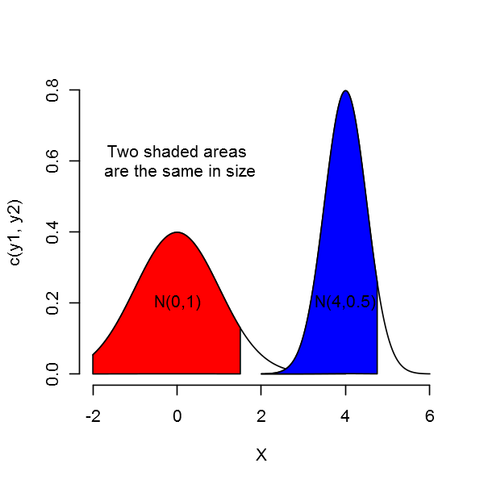

```r
options(repr.plot.height=5)
x1 <- seq(-2,4,0.01)
x1a <- seq(-2, 1.5, 0.01)
y1 <- dnorm(x1, 0,1)
x2 <- seq(2,6,0.01)
x2a <- seq(2,4.75, 0.01)
y2 <- dnorm(x2, 4, 0.5)
plot(c(x1,x2),c(y1,y2), xlab="X", type="l", bty="n")
polygon(c(x1a, rev(x1a)), c(dnorm(x1a, 0,1), 0.001*dnorm(rev(x1a),0,1)), col="red")
polygon(c(x2a, rev(x2a)), c(dnorm(x2a, 4,0.5), 0.001*dnorm(rev(x2a),4,0.5)), col="blue")
text(0,0.6,"Two shaded areas\n are the same in size")
text(0,0.2,"N(0,1)")
text(4,0.2,"N(4,0.5)")
```

위의 두 p.d.f를 보시기 바랍니다. 파라미터의 값에 따라 같은 정규 분포지만 다른 형태와 위치를 갖는 것을 확인할 수 있습니다. 기대값 파라미터는 분포의 중심을 결정하고, 표준편차 파라미터는 분포의 퍼진 정도를 결정합니다. 오른쪽 정규분포는 표준편차 값이 0.5로, 왼쪽 분포보다 폭이 절반 정도로 좁습니다.

왼쪽 p.d.f는 표준 정규 분포(standard normal distribution)를 나타내고 있습니다. 표준 정규 분포, 곧 N(0,1)을 따르는 확률 변수를 Z 라고 합니다.

정규 분포의 특성 상, 어떤 파라미터를 갖는 정규분포도 모두 표준화를 시켜 원래의 확률 변수 값을 표준 정규 분포를 따르는 Z-score로 변환할 수 있습니다. Z-score를 구하는 방법은 각 확률 변수 값에서 분포의 평균을 빼고, 그 값을 분포의 표준 편차 값으로 나눠주면 됩니다.

위의 두 분포에서 색칠한 부분의 넓이는 같습니다. 오른쪽의 분포를 표준화(standardize)를 시키면 왼쪽의 분포와 같은 형태가 될 것입니다. 각 색칠한 부분은 z-score가 1.5 이하인 영역들입니다.

```r
# N(0,1) 분포에서 25th quantile에 해당하는 값을 리턴합니다.
qnorm(.25)
# N(0,1) 분포에서 F(1) - F(-1)값을 리턴합니다. 다시 말해 one standard deviation
# from the mean에 얼마만큼의 자료가 분포하는 지 살펴보는 함수입니다.
# 아래에 실제 p.d.f 에서 구간을 확인해 보시기 바랍니다.
pnorm(1)-pnorm(-1)
```

-0.674489750196082

0.682689492137086

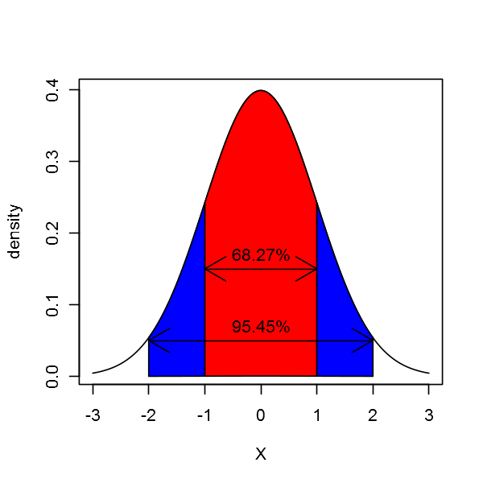

```r
z1 <- seq(-3, 3, 0.01)
z1a <- seq(-1,1,0.01)
z2 <- seq(-2,-1,0.01)
z2a <- seq(1,2,0.01)
zy1 <- dnorm(z1, 0, 1)
zy1a <- dnorm(z1a, 0,1)
plot(z1, zy1, type="l", xlab="X", ylab="density")
polygon(c(z1a, rev(z1a)), c(zy1a, 0.001*dnorm(z1a, 0, 1)), col="red")
polygon(c(z2, rev(z2)), c(dnorm(z2, 0,1), 0.001*dnorm(rev(z2),0,1)), col="blue")
polygon(c(z2a, rev(z2a)), c(dnorm(z2a, 0,1), 0.001*dnorm(rev(z2a),0,1)), col="blue")
arrows(-1,0.15,1,0.15,code=3)
text(0, 0.17, "68.27%")
arrows(-2,0.05,2,0.05,code=3)
text(0,0.07, "95.45%")
```

### 5.2.3 Popular distributions to describe populations

*Uniform distribution*

구간 [a,b] 에서 정의되는 균등 분포(uniform distribution)는 확률 변수가 가질 수 있는 값들이 모두 확률이 같습니다. 앞에서도 몇 번 보았지만, 밀도가 구간 [a,b] 에서 일정합니다. p.d.f 아래 영역의 넓이는 확률이라고 이야기 했었고, 확률의 총 합은 1이기 때문에 균등 분포의 p.d.f의 높이는 1/(b-a) 입니다. 평균은 (a+b)/2로 구할 수 있습니다. 분산 공식은 $E[X-E[X]^2]$를 사용해서 구하면 됩니다. 자세한 풀이는 http://math.stackexchange.com/questions/728059/prove-variance-in-uniform-distribution-continuous 로 대체하겠습니다.

*Exponential distribution*

*Lognormal distribution*

매우 skewed 된 연속 분포입니다. 이 분포의 특징은 확률 변수 X는 정규 분포를 따르지 않지만, log(X)는 정규 분포를 따릅니다. 특징적인 건, 나중에 회귀분석을 할 때 잔차가 정규 분포를 따르지 않을 경우에, log-transformation 이라는 기법을 써서 정규분포를 따르게끔 하는 방법이 있습니다. 만약 확률 변수 X에 log를 씌웠을 때 잔차가 정규 분포를 따른다면, 그 자료는 lognormal 분포를 따른다고 말할 수 있습니다. 역시 우선은 이런 것이 있다 정도만 알아 두시면 좋을 것 같습니다.

### 5.2.4 Sampling distributions

여태까지는 모집단의 분포를 나타내는 분포들을 살펴봤습니다. 실제로 우리는 모집단에 대해 분석을 하지 않고, 표본 집단을 대상으로 분석을 진행하기 때문에 조금 다른 분포들을 사용합니다.

- t-분포: 정규 분포와 형태가 유사하며, 집단의 크기(n)가 작을 때 가정하는 분포입니다.
- F-분포: 집단 간 차이가 집단 내 차이보다 유의미하게 큰 지를 보기 위해서 사용합니다. 나중에 ANOVA를 배울 때 다시 나올겁니다.
- $\chi^2$-분포: k 개의 독립적인 z-score 들을 제곱해서 그 값들을 더해서 구합니다.